# Lab 11: Gibbs Sampling and Langevin Proposals

STAT 536 — Statistical Computing (solutions)

Author

Soumojit Das

Published

Fall 2026

# Setup

Figure labels are typeset by LaTeX. `tikz_png()` draws a ggplot through `tikzDevice`, compiles it with `pdflatex`, and returns a PNG. It needs a LaTeX installation (TinyTeX is enough) and installs `tikzDevice`, `pdftools`, and `png` on first use. All three problems use `effectiveSize()` from the `coda` package, which the setup chunk installs if it is missing. Problem 1 uses the data `coal` from the `boot` package, which comes with R. The three problems do not use Stan.

```r
library(ggplot2)
library(patchwork)
if (!requireNamespace("coda", quietly = TRUE)) install.packages("coda")
set.seed(536)
theme_set(theme_bw(base_size = 14))

pal <- c(red = "#D62828", blue = "#2E86AB", green = "#06A77D",
         orange = "#F77F00", dark = "#023047", grey = "#6a6a6a")

find_pdflatex <- function() {
  tinytex <- c("~/Library/TinyTeX/bin/universal-darwin/pdflatex",
               file.path(Sys.getenv("APPDATA"),
                         "TinyTeX/bin/windows/pdflatex.exe"),
               "~/.TinyTeX/bin/x86_64-linux/pdflatex")
  cand <- c(Sys.which("pdflatex"), path.expand(tinytex))
  cand <- cand[nzchar(cand) & file.exists(cand)]
  if (!length(cand))
    stop("pdflatex not found; install TinyTeX with ",
         "tinytex::install_tinytex()")
  cand[[1]]
}

tikz_png <- function(p, png_file, width = 9, height = 5, dpi = 150) {
  for (pkg in c("tikzDevice", "pdftools", "png"))
    if (!requireNamespace(pkg, quietly = TRUE)) install.packages(pkg)
  options(
    tikzLatex = find_pdflatex(),
    tikzDocumentDeclaration = r"(\documentclass[10pt]{article})",
    tikzLatexPackages = c(
      r"(\usepackage{tikz})",
      r"(\usepackage[active,tightpage,psfixbb]{preview})",
      r"(\PreviewEnvironment{pgfpicture})",
      r"(\setlength\PreviewBorder{0pt})",
      r"(\usepackage[T1]{fontenc})", r"(\usepackage{lmodern})",
      r"(\usepackage{amsmath})"))
  work <- file.path(tempdir(), "tikz_png")
  dir.create(work, showWarnings = FALSE)
  tex <- file.path(work, "fig.tex")
  pdf <- file.path(work, "fig.pdf")
  tikzDevice::tikz(tex, width = width, height = height, standAlone = TRUE)
  print(p)
  dev.off()
  ok <- system2(getOption("tikzLatex"),
                c("-interaction=batchmode", "-halt-on-error",
                  paste0("-output-directory=", shQuote(work)),
                  shQuote(tex)),
                stdout = FALSE, stderr = FALSE)
  if (ok != 0 || !file.exists(pdf))
    stop("pdflatex failed; see ", file.path(work, "fig.log"))
  dir.create(dirname(png_file), recursive = TRUE, showWarnings = FALSE)
  png::writePNG(pdftools::pdf_render_page(pdf, page = 1, dpi = dpi),
                png_file)
  png_file
}

# tick labels in math mode, so minus signs and decimals are set by LaTeX
tex_num <- function(v) ifelse(is.na(v), NA,
  paste0("$", format(v, scientific = FALSE, drop0trailing = TRUE,
                     trim = TRUE), "$"))
tex_theme <- theme(text = element_text(size = 17),
                   plot.title = element_text(hjust = 0.5),
                   legend.position = "top",
                   legend.key.width = unit(1.2, "cm"))
# whole-number ticks for a time axis
int_breaks <- function(lim) unique(round(pretty(lim)))
```

# Notation

The lab uses these symbols.

| Symbol | Meaning |
| --- | --- |
| $\mathbf{x} = (x_1, \ldots, x_n)$ | the data: the counts of $n = 112$ years in Problem 1 (`y` in the code), the failure counts of $n = 10$ pumps in Problem 3 |
| $\lambda_1$, $\lambda_2$ | in Problem 1, the Poisson rates before and after the change |
| $k$ | the change point: years $1, \ldots, k$ have rate $\lambda_1$, and the change year is $1850 + k$ |
| $a$, $b$ | the shape and the rate of the Gamma prior on the rates: fixed numbers in Problem 1, unknowns in Problem 3 |
| $S_k$ | $x_1 + \cdots + x_k$ |
| $w_k$ | the weight of $k$ in its full conditional |
| $\pi(k \mid \mathbf{x})$ | the exact posterior of $k$, with the rates integrated out |
| $\pi$ | the target density, a posterior in Problems 1 and 3 |
| $x$, $Y$ | in Problem 2, the current state and the proposal |
| $\epsilon$ | the Langevin step size |
| $Z$ | in Problem 2, the $\Normal(\mathbf{0}, \mathbf{I})$ noise of the proposal. In Problem 3, the $\Normal(0, s^2)$ step of $\log a$ |
| $q(y \mid x)$ | the proposal density from $x$ to $y$ |
| $\alpha(x, y)$ | the acceptance probability |
| $\phi(y; \mathbf{m}, \mathbf{S})$ | the normal density at $y$, with mean $\mathbf{m}$ and covariance $\mathbf{S}$ |
| $d$ | the dimension of the target in Problem 2 |
| $s$ | the standard deviation of a random-walk step: on $x$ in Problem 2, on $\log a$ in Problem 3 |
| $t_i$, $\theta_i$ | in Problem 3, the operating time of pump $i$ in thousands of hours, and its failure rate per thousand hours |
| $\boldsymbol\theta$ | the ten rates together, $(\theta_1, \ldots, \theta_n)$ |
| $a^*$ | in Problem 3, the proposed value of $a$ |
| $N$ | the number of sweeps or iterations |
| ESS, MCSE | the effective sample size from `coda::effectiveSize()`, and the Monte Carlo standard error $\text{sd}/\sqrt{\text{ESS}}$ |

Every problem ends with a **Report** list. Interpretation references the specific values you computed, not generic textbook claims.

# Problem 1: Gibbs Sampling for a Change Point

The `coal` data of the `boot` package give, in the words of its help page, “the dates of 191 explosions in coal mines which resulted in 10 or more fatalities”, from March 15, 1851 until March 22, 1962. We count the explosions by year. With $n = 112$ years, $x_i$ is the count in the year $1850 + i$. This is the change-point model of the lecture.

**NoteChange-point model**

$X_i \sim \Pois(\lambda_1)$ for $i \le k$ and $X_i \sim \Pois(\lambda_2)$ for $i > k$, independently. The priors are $\lambda_1, \lambda_2 \iid \Gam(a, b)$, with $a = 2$ and rate $b = 1$, and $k$ uniform on $\{1, \ldots, n - 1\}$. The change year $1850 + k$ is the last year at rate $\lambda_1$. With $S_k = x_1 + \cdots + x_k$, the full conditionals are

$$\lambda_1 \mid \lambda_2, k, \mathbf{x} \sim \Gam(a + S_k,\ b + k),$$

$$\lambda_2 \mid \lambda_1, k, \mathbf{x} \sim \Gam(a + S_n - S_k,\ b + n - k),$$

$$\pi(k \mid \lambda_1, \lambda_2, \mathbf{x}) = \frac{w_k}{\sum_{j=1}^{n-1} w_j}, \qquad \log w_k = S_k\log\frac{\lambda_1}{\lambda_2} - k(\lambda_1 - \lambda_2).$$

A sweep draws $\lambda_1$, then $\lambda_2$, then $k$, each from its full conditional given the newest values of the others. The rates integrate out in closed form, which gives the exact posterior of $k$ as a check:

$$\pi(k \mid \mathbf{x}) \propto \frac{\Gamma(a + S_k)}{(b + k)^{a + S_k}} \cdot \frac{\Gamma(a + S_n - S_k)}{(b + n - k)^{a + S_n - S_k}}.$$

1. Complete `gibbs_coal(N, y, a, b, k0)` below, with `k0` the starting value of $k$. It returns one row per sweep, with the columns $\lambda_1$, $\lambda_2$, $k$. Compute the log weights, subtract their maximum before `exp()`, and draw $k$ with `sample()`, which normalizes the weights. Recall why we subtract the maximum, from the log-sum-exp trick of week 1? Run the sampler with $N = 21000$ from $k_0 = 56$ and discard the first 1000 sweeps. Compute the posterior means of $\lambda_1$ and $\lambda_2$, and the five most probable change years with their probabilities.
2. Compute the exact $\pi(k \mid \mathbf{x})$ of the callout on the log scale, with `lgamma()`, and normalize it. Compute the largest absolute difference between the Gibbs relative frequencies of $k$ and the exact probabilities. Run the figure chunk. It draws both for the change years 1880 to 1900.
3. From the kept draws, answer three questions. Each is one line of R on the draws.
   - $P(\lambda_1/\lambda_2 > 3 \mid \mathbf{x})$, with its Monte Carlo standard error. Along the chain, the indicator of $\lambda_1/\lambda_2 > 3$ is a chain of its own, so its standard error is $\text{sd}/\sqrt{\text{ESS}}$ with the ESS of the indicator.
   - The posterior mean of $\lambda_1/\lambda_2$, and its 2.5% and 97.5% posterior quantiles.
   - The shortest run of consecutive change years that holds at least 95% of the posterior probability. The function `shortest_run()` in the code chunk finds it from the Gibbs frequencies.
4. Start the sampler at $k_0 = 110$, the year 1960. Run 200 chains of 50 sweeps each, one after the other, after one `set.seed(536)`. For each chain, find the first sweep at which $k$ is inside the run of task 3. Run the figure chunk, which draws the change year over the first 15 sweeps of every chain. The code chunk prints the slowest chain up to the sweep at which it got inside. Explain, with the full conditionals of the callout, what kept it where it was. Last, compute the ESS of $\lambda_1$, $\lambda_2$, and $k$ for the run of task 1.

```r
set.seed(536)
y <- as.integer(table(factor(floor(boot::coal$date), levels = 1851:1962)))
n <- length(y)
a <- 2
b <- 1

gibbs_coal <- function(N, y, a, b, k0) {
  n <- length(y)
  S <- cumsum(y)
  ks <- 1:(n - 1)
  draws <- matrix(NA_real_, N, 3,
                  dimnames = list(NULL, c("lambda1", "lambda2", "k")))
  k <- k0
  for (t in 1:N) {
    # lambda1 and lambda2 from their full conditionals
    lambda1 <- rgamma(1, a + S[k], rate = b + k)
    lambda2 <- rgamma(1, a + S[n] - S[k], rate = b + n - k)
    # log w_k for k = 1, ..., n - 1
    log_w <- S[ks] * log(lambda1 / lambda2) - ks * (lambda1 - lambda2)
    # the weights, after subtracting the largest log weight
    w <- exp(log_w - max(log_w))
    # k from its full conditional; sample() normalizes w
    k <- sample(ks, 1, prob = w)
    draws[t, ] <- c(lambda1, lambda2, k)
  }
  draws
}

N <- 21000
B <- 1000
run1 <- gibbs_coal(N, y, a, b, k0 = 56)
kept <- run1[-(1:B), ]
print(colMeans(kept[, c("lambda1", "lambda2")]))
# the relative frequency of each k = 1, ..., n - 1
p_gibbs <- tabulate(kept[, "k"], nbins = n - 1) / nrow(kept)
top5 <- order(p_gibbs, decreasing = TRUE)[1:5]
print(data.frame(year = 1850 + top5, k = top5, prob = p_gibbs[top5]))
```

```
  lambda1   lambda2
3.0927673 0.9368882
  year  k    prob
1 1891 41 0.24115
2 1890 40 0.18390
3 1889 39 0.14510
4 1887 37 0.10000
5 1892 42 0.09300
```

```r
set.seed(536)
S <- cumsum(y)
ks <- 1:(n - 1)
# the shapes and the rates of the two Gamma integrals
a1 <- a + S[ks]
b1 <- b + ks
a2 <- a + S[n] - S[ks]
b2 <- b + n - ks
# log pi(k | x), up to a constant
log_p <- lgamma(a1) - a1 * log(b1) + lgamma(a2) - a2 * log(b2)
p_exact <- exp(log_p - max(log_p))
p_exact <- p_exact / sum(p_exact)
print(sprintf("Largest absolute difference: %.4f",
              max(abs(p_gibbs - p_exact))))
```

```
[1] "Largest absolute difference: 0.0033"
```

Run the figure chunk. The bars are the Gibbs relative frequencies and the points the exact probabilities.

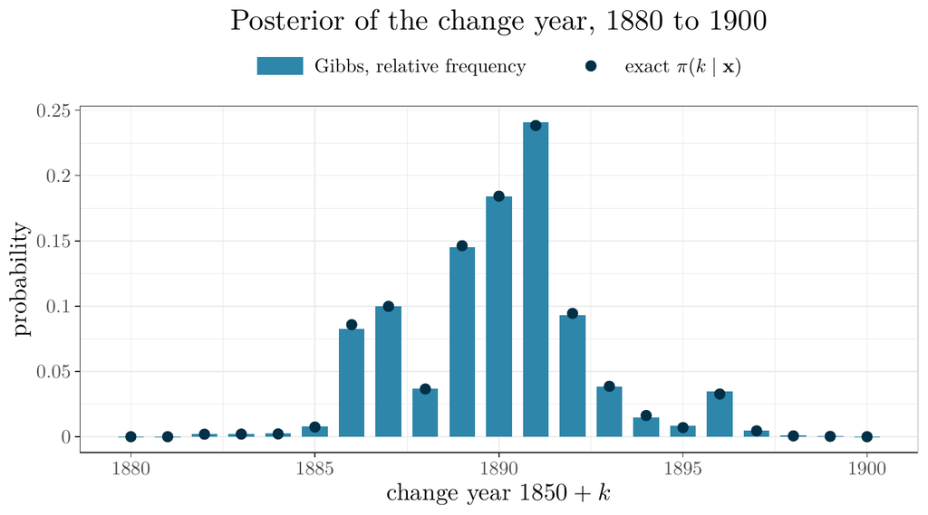

```r
set.seed(536)
shown <- 1880:1900
lev <- c("Gibbs, relative frequency", r"(exact $\pi(k \mid \mathbf{x})$)")
df_post <- data.frame(year = shown, gibbs = p_gibbs[shown - 1850],
                      exact = p_exact[shown - 1850])
p <- ggplot(df_post) +
  geom_col(aes(year, gibbs, fill = lev[1]), width = 0.7) +
  geom_point(aes(year, exact, color = lev[2]), size = 3) +
  scale_fill_manual(values = setNames(pal[["blue"]], lev[1]),
                    name = NULL) +
  scale_color_manual(values = setNames(pal[["dark"]], lev[2]),
                     name = NULL) +
  # a fixed order for the two legends, which ggplot2 otherwise chooses
  guides(fill = guide_legend(order = 1), color = guide_legend(order = 2)) +
  scale_x_continuous(breaks = seq(1880, 1900, 5), labels = tex_num) +
  scale_y_continuous(labels = tex_num) +
  labs(title = "Posterior of the change year, 1880 to 1900",
       x = "change year $1850 + k$", y = "probability") +
  tex_theme

knitr::include_graphics(tikz_png(p, "figures/lab11/change-year.png",
                                 width = 9, height = 5))
```

```r
set.seed(536)
ratio <- kept[, "lambda1"] / kept[, "lambda2"]
# the indicator of lambda1 / lambda2 > 3, as 0s and 1s
above <- as.numeric(ratio > 3)
# its Monte Carlo standard error, from the ESS of the indicator
mcse_above <- sd(above) / sqrt(unname(coda::effectiveSize(above)))
print(sprintf("P(ratio > 3 | x): %.4f, MCSE %.4f",
              mean(above), mcse_above))
print(sprintf("Ratio: mean %.3f, 2.5%% quantile %.3f, 97.5%% quantile %.3f",
              mean(ratio), quantile(ratio, 0.025), quantile(ratio, 0.975)))

# the shortest run k = i, ..., j with p_i + ... + p_j >= level, and
# among runs of that length the one with the most probability
shortest_run <- function(p, level = 0.95) {
  m <- length(p)
  runs <- t(sapply(1:m, function(i) {
    cum <- cumsum(p[i:m])
    j <- which(cum >= level)[1]
    c(from = i, to = i + j - 1, prob = cum[j])
  }))
  runs <- runs[!is.na(runs[, "to"]), ]
  len <- runs[, "to"] - runs[, "from"]
  runs[order(len, -runs[, "prob"])[1], ]
}
run95 <- shortest_run(p_gibbs)
print(sprintf("Shortest 95%% run: %d to %d, probability %.4f",
              1850 + run95[["from"]], 1850 + run95[["to"]],
              run95[["prob"]]))
```

```
[1] "P(ratio > 3 | x): 0.7442, MCSE 0.0031"
[1] "Ratio: mean 3.351, 2.5% quantile 2.466, 97.5% quantile 4.468"
[1] "Shortest 95% run: 1886 to 1896, probability 0.9788"
```

```r
set.seed(536)
R <- 200
chains <- lapply(1:R, function(r) gibbs_coal(50, y, a, b, k0 = 110))
in_run <- function(k) k >= run95[["from"]] & k <= run95[["to"]]
# for each chain, the first sweep with k inside the run of task 3
first_in <- sapply(chains, function(ch) which(in_run(ch[, "k"]))[1])
print(sprintf("Share inside after one sweep: %.3f", mean(first_in == 1)))
print(sprintf("Largest first sweep:          %d", max(first_in)))
slowest <- chains[[which.max(first_in)]]
print(round(slowest[1:max(first_in), ], 3))

# the ESS of each unknown, for the run of task 1
print(round(apply(kept, 2, function(z) coda::effectiveSize(z))))
```

```
[1] "Share inside after one sweep: 0.415"
[1] "Largest first sweep:          10"
      lambda1 lambda2  k
 [1,]   1.864   0.324 97
 [2,]   1.978   0.360 92
 [3,]   1.816   0.338 97
 [4,]   1.963   0.174 98
 [5,]   1.761   0.261 98
 [6,]   1.841   0.376 97
 [7,]   1.953   0.351 97
 [8,]   1.807   0.303 92
 [9,]   2.058   0.392 92
[10,]   2.173   0.880 42
lambda1 lambda2       k
  16295   16983   15589
```

Run the figure chunk. Sweep 0 is the start. The dashed lines bound the run of task 3, and the slowest chain is in red.

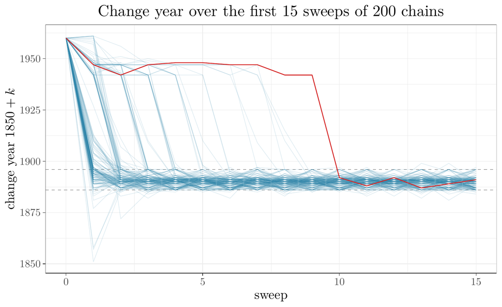

```r
set.seed(536)
sweeps <- 15
df_k <- data.frame(
  chain = rep(1:R, each = sweeps + 1),
  sweep = rep(0:sweeps, times = R),
  year = 1850 + unlist(lapply(chains, function(ch)
    c(110, ch[1:sweeps, "k"]))))
p <- ggplot(df_k, aes(sweep, year, group = chain)) +
  geom_hline(yintercept = 1850 + c(run95[["from"]], run95[["to"]]),
             linetype = "dashed", color = pal[["grey"]]) +
  geom_line(color = pal[["blue"]], alpha = 0.15) +
  geom_line(data = df_k[df_k$chain == which.max(first_in), ],
            color = pal[["red"]], linewidth = 1) +
  scale_x_continuous(breaks = int_breaks, labels = tex_num) +
  scale_y_continuous(labels = tex_num) +
  labs(title = "Change year over the first 15 sweeps of 200 chains",
       x = "sweep", y = "change year $1850 + k$") +
  tex_theme

knitr::include_graphics(tikz_png(p, "figures/lab11/burn-in.png",
                                 width = 9, height = 5.5))
```

**Report.**

1. From task 1: the two posterior means, and the table of the five most probable change years.
2. From task 2: the largest absolute difference, with the figure.
3. From task 3: $P(\lambda_1/\lambda_2 > 3 \mid \mathbf{x})$ with its standard error, the posterior mean and the 95% interval of the ratio, and the shortest run with its probability.
4. From task 4: the share of chains inside the run after one sweep, the largest first sweep, the figure, and two or three sentences on what kept the slowest chain where it was.
5. The three ESS values, and one sentence on whether discarding 1000 sweeps was enough for the run of task 1.

**Task 1.** The posterior means of the rates are 3.093 explosions per year before the change and 0.937 after it. The five most probable change years are 1891 (probability 0.241), 1890 (0.184), 1889 (0.145), 1887 (0.100), and 1892 (0.093). The exact probabilities of task 2 rank the same five years in the same order.

**Task 2.** The largest absolute difference between the Gibbs frequencies and the exact probabilities is 0.0033, at the change year 1886, where the exact probability is 0.0859. The indicator of $k = 36$ has ESS 18,610, which gives that frequency a Monte Carlo standard error of 0.0021. The largest difference is 1.59 standard errors.

**Task 3.** The draws estimate $P(\lambda_1/\lambda_2 > 3 \mid \mathbf{x})$ at 0.7442, with Monte Carlo standard error 0.0031. The ESS of the indicator is 20,000 of 20,000. Its lag-1 autocorrelation is 0.0009, so the autoregression that `coda` fits to it has order 0, and the ESS equals $N$. This probability also has an exact value. Given $k$, the two rates are independent Gamma variables, and $\lambda_1/\lambda_2 > 3$ is a tail event of a Beta variable:

$$P\Bigl(\frac{\lambda_1}{\lambda_2} > 3 \Bigm| \mathbf{x}\Bigr) = \sum_{k=1}^{n-1}\pi(k \mid \mathbf{x})\,P\Bigl(B_k > \frac{3(b + k)}{3(b + k) + b + n - k}\Bigr),$$

$$B_k \sim \Betad(a + S_k,\ a + S_n - S_k).$$

With the vectors of task 2 this is `sum(p_exact * pbeta(3 * b1 / (3 * b1 + b2), a1, a2, lower.tail = FALSE))`, which gives 0.7410. The Gibbs estimate is 1.05 standard errors from it. The posterior mean of the ratio is 3.351, against the exact $\sum_k \pi(k \mid \mathbf{x})\,\frac{a + S_k}{b + k}\cdot\frac{b + n - k}{a + S_n - S_k - 1} = 3.348$. Its 95% interval is $[2.47, 4.47]$. With posterior probability 0.95, the rate before the change was between 2.5 and 4.5 times the rate after it. The shortest run of change years with probability at least 0.95 is 1886 to 1896, 11 years, with probability 0.979. The exact probabilities give the same run, with probability 0.981.

**Task 4.** Of the 200 chains, 83 were inside the run after one sweep, a share of 0.415. Within two sweeps the share is 0.740. The slowest chain got inside at sweep 10. In the figure most chains drop from 1960 into the run within two sweeps, and the red one stays near 1947 for 9 sweeps.

About a third of the chains get near 1947 on the first sweep. With $k_0 = 110$, $\lambda_2 \mid \lambda_1, k, \mathbf{x} \sim \Gam(3, 3)$, from the 2 years after 1960 with 1 explosion, so the first draw of $\lambda_2$ rests on almost no data. 70 of the 200 chains, about a third, landed at $k \ge 90$ on the first sweep.

The slowest chain had $k$ between 92 and 98, the years 1942 to 1948, for 9 sweeps. With $k = 97$, $\lambda_2 \mid \lambda_1, k, \mathbf{x} \sim \Gam(6, 16)$, with mean 0.38, since the 15 years after 1947 had 4 explosions. $\lambda_1 \mid \lambda_2, k, \mathbf{x} \sim \Gam(189, 98)$, with mean 1.93, an average over the busy and the quiet decades before 1947. Moving the change from year $k - 1$ to year $k$ changes the log weight by $\log w_k - \log w_{k-1} = x_k\log(\lambda_1/\lambda_2) - (\lambda_1 - \lambda_2)$, which is positive when

$$x_k > \frac{\lambda_1 - \lambda_2}{\log(\lambda_1/\lambda_2)}.$$

At the rates the chain drew during its stay, on average $\lambda_1 = 1.89$ and $\lambda_2 = 0.32$, the right side is 0.88. The years from 1892, after the most probable change year, to 1947 averaged 1.07 explosions, so at these rates they count as years before the change. The years from 1948 to 1962 averaged 0.27. So the full conditional of $k$ puts the change near 1947 again, with its mode at 1947, and the rates drawn at that $k$ reproduce themselves.

The chain leaves when $\lambda_2$ is drawn high enough. At $\lambda_1 = 1.89$, the full conditional of $k$ puts probability one half on $k \ge 90$ when $\lambda_2 = 0.49$, and only 0.010 when $\lambda_2 = 0.6$. $\Gam(6, 16)$ exceeds 0.49 with probability 0.20, about one time in five. Over the 200 chains, 87 sweeps ended with $k$ between 95 and 99, and a share of 0.195 of them were followed by a sweep with $k < 90$. So the wait is roughly geometric, and the 9 sweeps of the slowest chain are its tail. It got out at sweep 10, when $\lambda_2$ was drawn at 0.88. Under the exact posterior, $P(k \ge 90 \mid \mathbf{x}) = 1.6 \times 10^{-9}$.

**ESS.** For the run of task 1, the ESS of $\lambda_1$, $\lambda_2$, and $k$ are 16,295, 16,983, and 15,589 of 20,000. That run was inside the run of task 3 from sweep 1. Among the 200 chains from 1960 the longest wait was 10 sweeps, so the 1000 discarded sweeps cover it 100 times over.

# Problem 2: The Langevin Proposal and Its Accept Step

The Langevin proposal takes a step along the gradient of $\log\pi$ and adds normal noise. This problem runs it under three accept rules, and then against the random walk as the dimension grows.

**NoteLangevin proposal**

From the state $x$, the proposal is

$$Y = x + \frac{\epsilon^2}{2}\nabla\log\pi(x) + \epsilon Z, \qquad Z \sim \Normal(\mathbf{0}, \mathbf{I}).$$

Its density is normal, centered at the gradient step from $x$, with standard deviation $\epsilon$ in every coordinate:

$$q(y \mid x) = \phi\Bigl(y;\ x + \frac{\epsilon^2}{2}\nabla\log\pi(x),\ \epsilon^2\mathbf{I}\Bigr).$$

The Metropolis–Hastings acceptance probability is

$$\alpha(x, y) = \min\Bigl(1,\ \frac{\pi(y)\,q(x \mid y)}{\pi(x)\,q(y \mid x)}\Bigr).$$

On $\Normal(0, 1)$ the gradient is $-x$. A chain that moves to every proposal is then an AR(1) chain,

$$X' = \Bigl(1 - \frac{\epsilon^2}{2}\Bigr)X + \epsilon Z,$$

and for $0 < \epsilon < 2$ its stationary variance is $1/(1 - \epsilon^2/4)$.

1. Complete `langevin()` below: the center of the proposal density in `log_q()`, the proposal, and the two log ratios. With `accept = "none"` the chain moves to every proposal. With `accept = "ratio"` a proposal is accepted with probability $\min(1, \pi(y)/\pi(x))$, the rule of the Metropolis algorithm of week 11. With `accept = "hastings"` it is accepted with the probability $\alpha(x, y)$ of the callout. Take $\pi = \Normal(0, 1)$, with `grad_norm()` and `log_pi_norm()` from the code chunk. Run the chain with `accept = "none"`, $N = 10^5$, and $x_0 = 0$, at $\epsilon = 0.5$, 1, and 1.5. For each run, compute the variance of the draws and the share of draws inside $(-1.96, 1.96)$, where the target has 0.95. Complete `theory` in the code chunk, and compare the variances with $1/(1 - \epsilon^2/4)$. Then run 100 steps at $\epsilon = 2.1$ from $x_0 = 1$, and print $\lvert x\rvert$ after 10, 25, 50, and 100 steps.
2. Run the chain with `accept = "ratio"` and with `accept = "hastings"` at the same three step sizes, with everything else as in task 1. Every run starts from `set.seed(536)`. The code chunk prints the acceptance rate, the variance, and the share inside $(-1.96, 1.96)$ for all nine runs. Run the figure chunk. It draws the three chains at $\epsilon = 1.5$ over the target density.
3. Recall the goal of tuning from week 12? A large ESS for the cost. Take $\pi = \Normal(\mathbf{0}, \mathbf{I})$ in $d$ dimensions, which is $d$ independent standard normal coordinates, for $d = 2$, 10, 50, and 100. Compare two samplers over $N = 20000$ iterations.
   - The random walk of week 12, $Y = x + sZ$, with $s = 2.38/\sqrt d$. It is `rw_metropolis()` in the code chunk.
   - The Langevin proposal with `accept = "hastings"`, with $\epsilon = 1.65\,d^{-1/6}$.

   Both scales shrink as $d$ grows, at the rate that the theory for large $d$ recommends for each sampler. Each chain starts at a draw from the target, `rnorm(d)`, so there is no burn-in to discard. An iteration of the random walk costs one evaluation of $\log\pi$. An iteration of the Langevin sampler costs one evaluation of $\log\pi$ and one of its gradient, when the values at the current state are stored. Count it as two evaluations. For each $d$ and each sampler, compute the acceptance rate, the ESS of the first coordinate, and the ESS per evaluation. Run the figure chunk. It draws the ESS per evaluation against $d$, on log axes.

```r
set.seed(536)
# One Langevin chain. grad is the gradient of log pi, and log_pi is
# log pi up to a constant. accept is "none", "ratio", or "hastings".
# To keep the code short, it recomputes log pi and the gradient at the
# current state in every iteration. A version that stores them needs
# one new evaluation of each per iteration.
langevin <- function(N, eps, x0, grad, log_pi, accept) {
  d <- length(x0)
  chain <- matrix(NA_real_, N, d)
  x <- x0
  accepted <- 0
  # log q(to | from): independent normals around the gradient step
  log_q <- function(to, from) {
    # the center of the proposal density, from the state `from`
    center <- from + eps^2 / 2 * grad(from)
    sum(dnorm(to, center, eps, log = TRUE))
  }
  for (t in 1:N) {
    # the proposal
    y <- x + eps^2 / 2 * grad(x) + eps * rnorm(d)
    if (accept == "none") {
      log_r <- Inf
    } else if (accept == "ratio") {
      # the log of pi(y) / pi(x)
      log_r <- log_pi(y) - log_pi(x)
    } else {
      # the log of the Hastings ratio, with log_q()
      log_r <- log_pi(y) - log_pi(x) + log_q(x, y) - log_q(y, x)
    }
    # with log_r = Inf the proposal is always accepted
    if (log(runif(1)) <= log_r) {
      x <- y
      accepted <- accepted + 1
    }
    chain[t, ] <- x
  }
  list(chain = chain, accept_rate = accepted / N)
}

grad_norm <- function(x) -x
log_pi_norm <- function(x) -sum(x^2) / 2

# the acceptance rate, the variance, and the share inside (-1.96, 1.96)
# of a chain on N(0, 1)
summarize_run <- function(run) {
  draws <- run$chain[, 1]
  c(accept = run$accept_rate, variance = var(draws),
    inside = mean(abs(draws) < 1.96))
}

N <- 1e5
eps_grid <- c(0.5, 1, 1.5)
runs_none <- lapply(eps_grid, function(eps) {
  set.seed(536)
  langevin(N, eps, 0, grad_norm, log_pi_norm, "none")
})
# the stationary variance of the callout, at the three step sizes
theory <- 1 / (1 - eps_grid^2 / 4)
tab_none <- cbind(eps = eps_grid, t(sapply(runs_none, summarize_run)),
                  theory = theory)
print(round(tab_none, 4))

set.seed(536)
run_big <- langevin(100, 2.1, 1, grad_norm, log_pi_norm, "none")
print(signif(abs(run_big$chain[c(10, 25, 50, 100), 1]), 3))
```

```
     eps accept variance inside theory
[1,] 0.5      1   1.0793 0.9414 1.0667
[2,] 1.0      1   1.3432 0.9096 1.3333
[3,] 1.5      1   2.3021 0.8040 2.2857
[1] 2.84e+01 4.41e+02 4.65e+04 5.21e+08
```

```r
set.seed(536)
rules <- c("none", "ratio", "hastings")
runs_all <- lapply(rules[-1], function(rule) {
  lapply(eps_grid, function(eps) {
    set.seed(536)
    langevin(N, eps, 0, grad_norm, log_pi_norm, rule)
  })
})
# the runs of task 1 come first
runs_all <- setNames(c(list(runs_none), runs_all), rules)
tab_rules <- do.call(rbind, lapply(rules, function(rule) {
  data.frame(rule = rule, eps = eps_grid,
             t(sapply(runs_all[[rule]], summarize_run)))
}))
print(tab_rules, digits = 3, row.names = FALSE)
```

```
     rule eps accept variance inside
     none 0.5  1.000    1.079  0.941
     none 1.0  1.000    1.343  0.910
     none 1.5  1.000    2.302  0.804
    ratio 0.5  0.886    0.513  0.994
    ratio 1.0  0.768    0.572  0.990
    ratio 1.5  0.643    0.699  0.981
 hastings 0.5  0.990    1.010  0.949
 hastings 1.0  0.921    1.005  0.949
 hastings 1.5  0.744    1.003  0.949
```

Run the figure chunk. The bars are the draws of each chain, and the line is the target density.

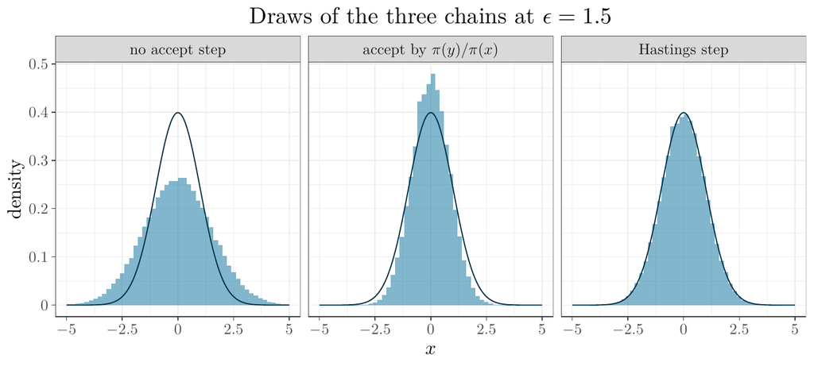

```r
set.seed(536)
lev <- c("no accept step", r"(accept by $\pi(y)/\pi(x)$)", "Hastings step")
# the draws of the three chains at eps = 1.5, the third step size
draws_15 <- lapply(rules, function(rule) runs_all[[rule]][[3]]$chain[, 1])
df_draws <- data.frame(x = unlist(draws_15),
                       rule = factor(rep(lev, each = N), levels = lev))
x_grid <- seq(-5, 5, length.out = 400)
df_target <- data.frame(x = x_grid, density = dnorm(x_grid))
p <- ggplot(df_draws, aes(x)) +
  geom_histogram(aes(y = after_stat(density)), breaks = seq(-5, 5, 0.2),
                 fill = pal[["blue"]], alpha = 0.6) +
  geom_line(data = df_target, aes(x, density), color = pal[["dark"]],
            linewidth = 0.9) +
  facet_wrap(~ rule, nrow = 1) +
  scale_x_continuous(labels = tex_num) +
  scale_y_continuous(labels = tex_num) +
  labs(title = r"(Draws of the three chains at $\epsilon = 1.5$)",
       x = "$x$", y = "density") +
  tex_theme

knitr::include_graphics(tikz_png(p, "figures/lab11/accept-rules.png",
                                 width = 10, height = 4.5))
```

```r
set.seed(536)
# Random-walk Metropolis on N(0, I). It returns the first coordinate
# and the acceptance rate.
rw_metropolis <- function(N, s, x0) {
  d <- length(x0)
  x <- x0
  lp <- log_pi_norm(x)
  x1 <- numeric(N)
  accepted <- 0
  for (t in 1:N) {
    y <- x + s * rnorm(d)
    lp_y <- log_pi_norm(y)
    if (log(runif(1)) <= lp_y - lp) {
      x <- y
      lp <- lp_y
      accepted <- accepted + 1
    }
    x1[t] <- x[1]
  }
  list(x1 = x1, accept_rate = accepted / N)
}

N_d <- 20000
d_grid <- c(2, 10, 50, 100)
tab_dim <- t(sapply(d_grid, function(d) {
  # the two scales at this d
  s <- 2.38 / sqrt(d)
  eps <- 1.65 / d^(1 / 6)
  set.seed(536)
  rw <- rw_metropolis(N_d, s, rnorm(d))
  set.seed(536)
  la <- langevin(N_d, eps, rnorm(d), grad_norm, log_pi_norm, "hastings")
  ess_rw <- unname(coda::effectiveSize(rw$x1))
  ess_la <- unname(coda::effectiveSize(la$chain[, 1]))
  # the ESS per evaluation of each sampler
  rw_per_eval <- ess_rw / N_d
  la_per_eval <- ess_la / (2 * N_d)
  c(d = d, rw_accept = rw$accept_rate, la_accept = la$accept_rate,
    rw_ess = ess_rw, la_ess = ess_la,
    rw_per_eval = rw_per_eval, la_per_eval = la_per_eval)
}))
# how many times the ESS per evaluation of the random walk
gain <- tab_dim[, "la_per_eval"] / tab_dim[, "rw_per_eval"]
tab_dim <- cbind(tab_dim, gain = gain)
# two tables, so each fits the page
print(signif(tab_dim[, c("d", "rw_accept", "la_accept",
                         "rw_ess", "la_ess")], 3))
print(signif(tab_dim[, c("d", "rw_per_eval", "la_per_eval", "gain")], 3))
```

```
       d rw_accept la_accept rw_ess la_ess
[1,]   2     0.351     0.624 2720.0  12200
[2,]  10     0.265     0.585  630.0   5640
[3,]  50     0.240     0.580  126.0   2930
[4,] 100     0.238     0.578   66.3   2110
       d rw_per_eval la_per_eval  gain
[1,]   2     0.13600      0.3060  2.25
[2,]  10     0.03150      0.1410  4.48
[3,]  50     0.00630      0.0731 11.60
[4,] 100     0.00331      0.0527 15.90
```

Run the figure chunk.

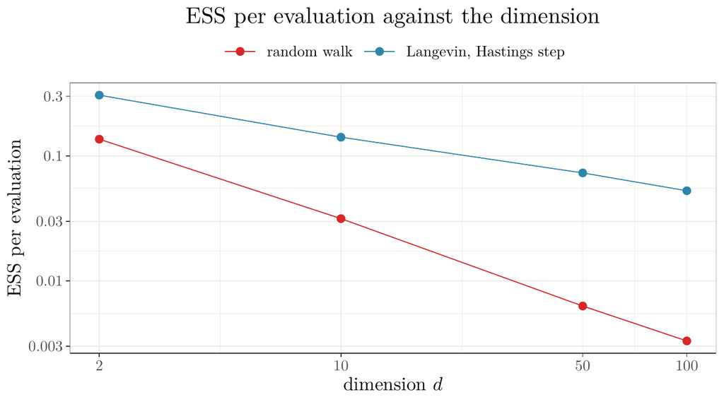

```r
set.seed(536)
lev <- c("random walk", "Langevin, Hastings step")
df_dim <- data.frame(
  d = rep(d_grid, 2),
  per_eval = c(tab_dim[, "rw_per_eval"], tab_dim[, "la_per_eval"]),
  sampler = factor(rep(lev, each = length(d_grid)), levels = lev))
p <- ggplot(df_dim, aes(d, per_eval, color = sampler)) +
  geom_line(linewidth = 0.8) +
  geom_point(size = 3) +
  scale_color_manual(values = setNames(unname(pal[c("red", "blue")]), lev),
                     name = NULL) +
  scale_x_log10(breaks = d_grid, labels = tex_num) +
  scale_y_log10(labels = tex_num) +
  labs(title = "ESS per evaluation against the dimension",
       x = "dimension $d$", y = "ESS per evaluation") +
  tex_theme

knitr::include_graphics(tikz_png(p, "figures/lab11/dimension.png",
                                 width = 9, height = 5))
```

**Report.**

1. From task 1: the table of the three variances against $1/(1 - \epsilon^2/4)$, with the shares inside $(-1.96, 1.96)$.
2. From task 1: the four values of $\lvert x\rvert$ at $\epsilon = 2.1$, and one sentence on what the chain does past $\epsilon = 2$, from its AR(1) form.
3. From task 2: the table of the nine runs, with the figure. State which of the three rules keep $\Normal(0, 1)$ stationary, and which chain is farthest from it at $\epsilon = 0.5$.
4. Two or three sentences that explain the three variances at $\epsilon = 0.5$. Say whether $q(y \mid x) = q(x \mid y)$ for this proposal.
5. From task 3: the two tables and the figure. Two or three sentences on how the ESS per evaluation of each sampler changes with $d$, and on which sampler you would use at $d = 100$.

**Task 1.** With no accept step, the variances of the draws are 1.079, 1.343, and 2.302 at $\epsilon = 0.5$, 1, and 1.5. The formula $1/(1 - \epsilon^2/4)$ gives 1.067, 1.333, and 2.286. Take as the Monte Carlo standard error of a variance that of the mean of $x^2$, $\text{sd}(x^2)/\sqrt{\text{ESS}}$ with the ESS of $x^2$. Each variance is within 1.6 such standard errors of the formula. All three exceed the target’s variance 1, and the excess grows with $\epsilon$. The shares inside $(-1.96, 1.96)$ are 0.941, 0.910, and 0.804, where the target has 0.95. A normal distribution with the formula’s variance puts 0.942, 0.910, and 0.805 there. So the chain samples the normal distribution of the callout, which is wider than the target.

At $\epsilon = 2.1$, $\lvert x\rvert$ is 28.4 after 10 steps, 441 after 25, 46,500 after 50, and $5.2 \times 10^{8}$ after 100. The AR(1) coefficient is $1 - \epsilon^2/2 = -1.205$, larger than 1 in absolute value. Once $\lvert x\rvert$ is large, each step flips the sign of $x$ and multiplies its size by about 1.205. From step 50 to step 100, $\lvert x\rvert$ grew by the factor 1.205 per step. So $\lvert x\rvert$ grows without bound, and the chain has no stationary distribution. At $\epsilon = 2$ the coefficient is $-1$, the edge of the range $0 < \epsilon < 2$ of the callout.

**Task 2.** The Hastings chain keeps $\Normal(0, 1)$ at every step size. Its variances are 1.010, 1.005, and 1.003, which are 0.83, 0.88, and 0.46 standard errors above 1, with the standard error of task 1. Its share inside $(-1.96, 1.96)$ is 0.949 at each step size. Its acceptance rates are 0.990, 0.921, and 0.744. The chain with `accept = "ratio"` does not keep the target. Its variances are 0.513, 0.572, and 0.699, and its shares inside are 0.994, 0.990, and 0.981. The chain with no accept step does not keep the target either, by task 1. At $\epsilon = 0.5$, the chain with `accept = "ratio"` is the farthest of the three from the target. Its variance is about half the target’s, where the chain with no accept step has a variance 8% too large.

The proposal is not symmetric. On $\Normal(0, 1)$,

$$q(y \mid x) = \phi\Bigl(y;\ \Bigl(1 - \frac{\epsilon^2}{2}\Bigr)x,\ \epsilon^2\Bigr), \qquad q(x \mid y) = \phi\Bigl(x;\ \Bigl(1 - \frac{\epsilon^2}{2}\Bigr)y,\ \epsilon^2\Bigr),$$

and the two are equal only when $x^2 = y^2$. Write $g$ for the $\Normal\bigl(0, 1/(1 - \epsilon^2/4)\bigr)$ density, which the chain with no accept step keeps stationary, and $\rho = 1 - \epsilon^2/2$. We have

$$g(x)\,q(y \mid x) \propto \exp\Bigl\{-\frac12\Bigl[\Bigl(1 - \frac{\epsilon^2}{4}\Bigr)x^2 + \frac{(y - \rho x)^2}{\epsilon^2}\Bigr]\Bigr\} = \exp\Bigl\{-\frac{x^2 - 2\rho xy + y^2}{2\epsilon^2}\Bigr\},$$

since the coefficient of $x^2$ is $1 - \epsilon^2/4 + \rho^2/\epsilon^2 = 1/\epsilon^2$. The right side is symmetric in $x$ and $y$, so

$$g(x)\,q(y \mid x) = g(y)\,q(x \mid y).$$

So the Hastings factor that the rule `"ratio"` leaves out is

$$\frac{q(x \mid y)}{q(y \mid x)} = \frac{g(x)}{g(y)}.$$

With `accept = "ratio"`, the chain moves from $x$ to $y \ne x$ with the density

$$K(x, y) = q(y \mid x)\min\Bigl(1,\ \frac{\pi(y)}{\pi(x)}\Bigr),$$

and

$$\pi(x)\,g(x)\,K(x, y) = g(x)\,q(y \mid x)\,\min\bigl(\pi(x), \pi(y)\bigr).$$

Both factors on the right are symmetric in $x$ and $y$, so

$$\pi(x)\,g(x)\,K(x, y) = \pi(y)\,g(y)\,K(y, x).$$

The chain satisfies detailed balance with the density proportional to $\pi(x)\,g(x)$, and

$$\pi(x)\,g(x) \propto e^{-x^2/2}\,e^{-(1 - \epsilon^2/4)x^2/2} = e^{-(2 - \epsilon^2/4)x^2/2},$$

which is the kernel of

$$\boxed{\Normal\Bigl(0,\ \frac{1}{2 - \epsilon^2/4}\Bigr)}.$$

Its variance is 0.516, 0.571, and 0.696 at the three step sizes, and the runs are within 0.7 standard errors of these. The gradient step of the proposal already pulls toward the center of $\pi$, and the accept step then applies $\pi$ a second time. In the figure at $\epsilon = 1.5$, the draws with no accept step spread wider than the line, those with the rule `"ratio"` are narrower, and those with the Hastings step follow it.

**Task 3.** The acceptance rates at $d = 2$, 10, 50, and 100 are 0.351, 0.265, 0.240, and 0.238 for the random walk, and 0.624, 0.585, 0.580, and 0.578 for the Langevin sampler. From $d = 10$ on they change little. The two scales shrink with $d$ at the rates under which the acceptance rate settles to a fixed value, and at $d = 100$ the rates are near 0.234 and 0.574, their limits for large $d$ at these scales. The acceptance rate is a diagnostic here. The goal is the ESS per evaluation.

The ESS per evaluation is 0.136, 0.0315, 0.0063, and 0.00331 for the random walk, and 0.306, 0.141, 0.0731, and 0.0527 for the Langevin sampler, which gives 2.25, 4.48, 11.6, and 15.9 times as much. From $d = 2$ to $d = 100$ the random walk loses a factor of 41.1 and the Langevin sampler a factor of 5.8. On the log axes of the figure these are slopes of $-0.95$ and $-0.45$. The theory for large $d$ gives the orders $1/d$ for the random walk (Roberts, Gelman, and Gilks, 1997) and $d^{-1/3}$ for the Langevin proposal (Roberts and Rosenthal, 1998), slopes $-1$ and $-1/3$. The random walk is close to its slope. The Langevin sampler falls faster than $d^{-1/3}$ over the whole range. From $d = 10$ to $d = 100$ alone its slope is $-0.43$. The order $d^{-1/3}$ is a limit for large $d$, which these dimensions have not reached.

At $d = 100$ the Langevin sampler gives 15.9 times the ESS per evaluation of the random walk, so it is the sampler to use. The random walk’s ESS there is 66 of 20,000. An ESS that small is itself a rough estimate, so the factor 15.9 is rough too.

On the slide “Langevin Against the Random Walk” of the lecture, the random walk had the larger ESS per iteration, and so the larger ESS per evaluation too. Its target, the bivariate normal with correlation 0.9, is narrow across its ridge, with standard deviation $\sqrt{1 - 0.9} = 0.316$ there. That capped $\epsilon$, so along the ridge the Langevin chain took short random-walk steps. $\Normal(\mathbf{0}, \mathbf{I})$ has no narrow direction, and the gradient pays more as the dimension grows.

# Problem 3: Gibbs Sampling with a Metropolis Step

Ten pumps at a nuclear power plant were observed for different lengths of time (Gaver and O’Muircheartaigh, 1987). Pump $i$ ran for $t_i$ thousand hours and failed $x_i$ times.

| Pump $i$ | 1 | 2 | 3 | 4 | 5 | 6 | 7 | 8 | 9 | 10 |
| --- | --- | --- | --- | --- | --- | --- | --- | --- | --- | --- |
| Failures $x_i$ | 5 | 1 | 5 | 14 | 3 | 19 | 1 | 1 | 4 | 22 |
| Time $t_i$ | 94.3 | 15.7 | 62.9 | 126 | 5.24 | 31.4 | 1.05 | 1.05 | 2.1 | 10.5 |

The question is the failure rate $\theta_i$ of each pump, per thousand hours. The raw rate $x_i/t_i$ rests on one failure for three of the pumps. So the model lets the pumps share information. The ten rates come from one Gamma distribution, and its shape and its rate are unknown too.

**NoteHierarchical model for the pumps**

$X_i \mid \theta_i \sim \Pois(\theta_i t_i)$, independently for $i = 1, \ldots, n$, with $n = 10$. The rates are $\theta_i \mid a, b \iid \Gam(a, b)$, with shape $a$ and rate $b$. The priors are $a \sim \Exp(1)$ and $b \sim \Gam(0.1, 1)$. The joint posterior is

$$\pi(\boldsymbol\theta, a, b \mid \mathbf{x}) \propto \prod_{i=1}^n\Bigl[\theta_i^{x_i}e^{-\theta_i t_i}\cdot\frac{b^a}{\Gamma(a)}\,\theta_i^{a - 1}e^{-b\theta_i}\Bigr]\cdot e^{-a}\cdot b^{0.1 - 1}e^{-b}.$$

The full conditionals of the rates and of $b$ are Gamma distributions:

$$\theta_i \mid a, b, \mathbf{x} \sim \Gam(a + x_i,\ b + t_i),$$

$$b \mid a, \boldsymbol\theta, \mathbf{x} \sim \Gam\Bigl(0.1 + na,\ 1 + \sum_{i=1}^n\theta_i\Bigr).$$

The full conditional of $a$ is the kernel of no named distribution:

$$\log\pi(a \mid b, \boldsymbol\theta, \mathbf{x}) = na\log b - n\log\Gamma(a) + (a - 1)\sum_{i=1}^n\log\theta_i - a + \text{const}.$$

So each sweep updates $a$ by one Metropolis–Hastings step, with the log-scale proposal of Lab 10. Propose $a^* = a\,e^{Z}$, with $Z \sim \Normal(0, s^2)$, and accept it with probability

$$\min\Bigl(1,\ \frac{\pi(a^* \mid b, \boldsymbol\theta, \mathbf{x})}{\pi(a \mid b, \boldsymbol\theta, \mathbf{x})}\cdot\frac{a^*}{a}\Bigr).$$

The step keeps the full conditional of $a$ stationary, so the sweep keeps the joint posterior stationary, as it does with an exact draw. A sweep draws the ten rates, then $b$, then takes the step for $a$.

The rates integrate out of the joint posterior, as in Problem 1. That leaves a density of $(a, b)$ alone,

$$\pi(a, b \mid \mathbf{x}) \propto e^{-a}\,b^{0.1 - 1}e^{-b}\prod_{i=1}^n\frac{\Gamma(a + x_i)}{\Gamma(a)}\cdot\frac{b^a}{(b + t_i)^{a + x_i}},$$

and the posterior mean of a rate is the posterior mean of $(a + x_i)/(b + t_i)$. A sum over a grid of $(a, b)$ gives the exact posterior means as a check.

1. Complete `log_cond_a()` and `gibbs_pumps()` below. Run the sampler with $N = 21000$ sweeps and $s = 1$ from $(a_0, b_0) = (1, 1)$, and discard the first 1000 sweeps. The next code chunk computes the exact posterior means with `exact_pumps()`. In it, complete the Monte Carlo standard error of each posterior mean. The chunk prints, for $a$, $b$, and the ten rates, the mean of the kept draws, the exact mean, and the number of standard errors between them.
2. The scale $s$ belongs to the step for $a$, and the goal of tuning it is a large ESS of $a$. Run the sampler at $s = 0.05$, 0.3, 1, and 3, each from `set.seed(536)`, with everything else as in task 1. For each run, compute the acceptance rate of the step, the ESS of $a$ and of $b$, and the smallest ESS among the ten rates.
3. Recall the posterior mean as a weighted average, from week 7? Given $a$ and $b$, the mean of the full conditional of $\theta_i$ is

   $$\frac{a + x_i}{b + t_i} = \frac{t_i}{b + t_i}\cdot\frac{x_i}{t_i} + \frac{b}{b + t_i}\cdot\frac{a}{b},$$

   a weighted average of the raw rate of pump $i$ and the mean $a/b$ of the Gamma distribution of the rates. For each pump, compute the raw rate $x_i/t_i$. From the kept draws of task 1, compute the posterior mean and the 2.5% and 97.5% posterior quantiles of $\theta_i$. Compute the weight $t_i/(b + t_i)$ on the raw rate, at the posterior mean of $b$. Run the figure chunk.

```r
set.seed(536)
# failures, and operating times in thousands of hours
x <- c(5, 1, 5, 14, 3, 19, 1, 1, 4, 22)
t_op <- c(94.3, 15.7, 62.9, 126, 5.24, 31.4, 1.05, 1.05, 2.1, 10.5)
n_pumps <- length(x)

# the log of the full conditional density of a, up to a constant
log_cond_a <- function(a, b, theta) {
  n <- length(theta)
  # the four terms of the callout
  n * a * log(b) - n * lgamma(a) + (a - 1) * sum(log(theta)) - a
}

gibbs_pumps <- function(N, s, x, t_op, a0, b0) {
  n <- length(x)
  draws <- matrix(NA_real_, N, n + 2,
                  dimnames = list(NULL, c("a", "b", paste0("theta", 1:n))))
  a <- a0
  b <- b0
  accepted <- 0
  for (sweep in 1:N) {
    # the n rates from their full conditionals, in one call
    theta <- rgamma(n, a + x, rate = b + t_op)
    # b from its full conditional
    b <- rgamma(1, 0.1 + n * a, rate = 1 + sum(theta))
    # the proposal for a, on the log scale
    a_star <- a * exp(rnorm(1, 0, s))
    # the log of the acceptance ratio, with the correction of Lab 10
    log_r <- log_cond_a(a_star, b, theta) - log_cond_a(a, b, theta) +
      log(a_star / a)
    if (log(runif(1)) <= log_r) {
      a <- a_star
      accepted <- accepted + 1
    }
    draws[sweep, ] <- c(a, b, theta)
  }
  list(draws = draws, accept_rate = accepted / N)
}

N <- 21000
B <- 1000
run_p <- gibbs_pumps(N, s = 1, x, t_op, a0 = 1, b0 = 1)
kept_p <- run_p$draws[-(1:B), ]
print(sprintf("Acceptance rate of the step for a: %.3f", run_p$accept_rate))
print(round(colMeans(kept_p[, c("a", "b")]), 3))
```

```
[1] "Acceptance rate of the step for a: 0.313"
    a     b
0.699 0.928
```

```r
set.seed(536)
# Exact posterior means. The rates integrate out, which leaves
# pi(a, b | x). The grid is on (log a, log b), over the box a_lim by
# b_lim, and la + lb is the log of the Jacobian a * b of that change
# of variables.
exact_pumps <- function(x, t_op, m = 600, a_lim = c(0.02, 8),
                        b_lim = c(1e-8, 30)) {
  la <- seq(log(a_lim[1]), log(a_lim[2]), length.out = m)
  lb <- seq(log(b_lim[1]), log(b_lim[2]), length.out = m)
  g <- expand.grid(la = la, lb = lb)
  a <- exp(g$la)
  b <- exp(g$lb)
  log_post <- -a + (0.1 - 1) * log(b) - b + g$la + g$lb
  for (i in seq_along(x)) {
    log_post <- log_post + lgamma(a + x[i]) - lgamma(a) +
      a * log(b) - (a + x[i]) * log(b + t_op[i])
  }
  w <- exp(log_post - max(log_post))
  w <- w / sum(w)
  theta_means <- sapply(seq_along(x), function(i) {
    sum(w * (a + x[i]) / (b + t_op[i]))
  })
  c(a = sum(w * a), b = sum(w * b),
    setNames(theta_means, paste0("theta", seq_along(x))))
}

exact <- exact_pumps(x, t_op)
ess_p <- apply(kept_p, 2, function(z) unname(coda::effectiveSize(z)))
# the Monte Carlo standard error of each posterior mean
mcse_p <- apply(kept_p, 2, sd) / sqrt(ess_p)
tab_p <- cbind(gibbs = colMeans(kept_p), exact = exact,
               z = (colMeans(kept_p) - exact) / mcse_p)
print(round(tab_p, 4))
```

```
         gibbs  exact       z
a       0.6991 0.6972  0.2807
b       0.9281 0.9268  0.1236
theta1  0.0597 0.0598 -0.8764
theta2  0.1015 0.1018 -0.5359
theta3  0.0891 0.0892 -0.6783
theta4  0.1155 0.1158 -1.4566
theta5  0.6041 0.6013  1.2365
theta6  0.6101 0.6094  0.6862
theta7  0.8905 0.8925 -0.3424
theta8  0.8961 0.8925  0.6653
theta9  1.5924 1.5863  0.9452
theta10 1.9916 1.9898  0.5553
```

```r
set.seed(536)
s_grid <- c(0.05, 0.3, 1, 3)
tab_s <- t(sapply(s_grid, function(s) {
  set.seed(536)
  run <- gibbs_pumps(N, s, x, t_op, a0 = 1, b0 = 1)
  ess <- apply(run$draws[-(1:B), ], 2,
               function(z) unname(coda::effectiveSize(z)))
  # the smallest ESS among the ten rates
  ess_theta_min <- min(ess[-(1:2)])
  c(s = s, accept = run$accept_rate, ess_a = ess[["a"]],
    ess_b = ess[["b"]], ess_theta_min = ess_theta_min)
}))
print(round(tab_s, 3))
```

```
        s accept    ess_a    ess_b ess_theta_min
[1,] 0.05  0.941   91.452  245.774       5290.89
[2,] 0.30  0.672 1284.642 2330.302      13952.15
[3,] 1.00  0.313 1603.238 2743.521      14317.45
[4,] 3.00  0.111  662.287 1230.020      11427.57
```

```r
set.seed(536)
theta_draws <- kept_p[, -(1:2)]
# the raw rate of each pump
raw <- x / t_op
post_mean <- colMeans(theta_draws)
lower <- apply(theta_draws, 2, quantile, 0.025)
upper <- apply(theta_draws, 2, quantile, 0.975)
a_bar <- mean(kept_p[, "a"])
b_bar <- mean(kept_p[, "b"])
# the weight on the raw rate, at the posterior mean of b
weight <- t_op / (b_bar + t_op)
tab_shrink <- data.frame(pump = 1:n_pumps, x = x, t = t_op, raw = raw,
                         post_mean = post_mean, lower = lower,
                         upper = upper, change = post_mean / raw - 1,
                         weight = weight)
print(signif(tab_shrink, 3), row.names = FALSE)
print(sprintf("a / b at the posterior means: %.3f", a_bar / b_bar))
```

```
 pump  x      t    raw post_mean   lower upper   change weight
    1  5  94.30 0.0530    0.0597 0.02130 0.118  0.12500  0.990
    2  1  15.70 0.0637    0.1010 0.00813 0.306  0.59300  0.944
    3  5  62.90 0.0795    0.0891 0.03170 0.176  0.12000  0.985
    4 14 126.00 0.1110    0.1150 0.06380 0.182  0.03930  0.993
    5  3   5.24 0.5730    0.6040 0.15200 1.360  0.05520  0.850
    6 19  31.40 0.6050    0.6100 0.37100 0.910  0.00821  0.971
    7  1   1.05 0.9520    0.8910 0.07510 2.760 -0.06490  0.531
    8  1   1.05 0.9520    0.8960 0.07590 2.750 -0.05910  0.531
    9  4   2.10 1.9000    1.5900 0.48500 3.410 -0.16400  0.694
   10 22  10.50 2.1000    1.9900 1.24000 2.910 -0.04950  0.919
[1] "a / b at the posterior means: 0.753"
```

Run the figure chunk. The open points are the raw rates. The filled points are the posterior means, and the vertical lines are the 95% intervals. The dashed line is $a/b$ at the posterior means of $a$ and $b$. The vertical axis is on a log scale.

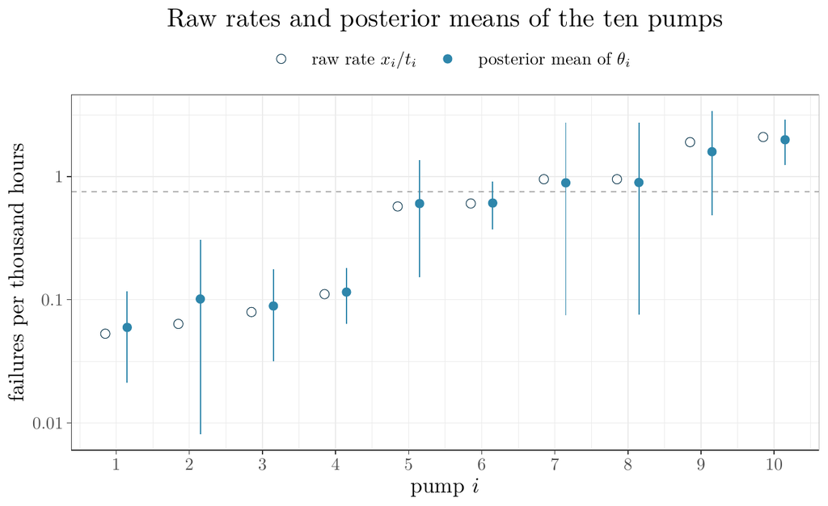

```r
set.seed(536)
lev <- c("raw rate $x_i / t_i$", r"(posterior mean of $\theta_i$)")
# the two points of a pump sit side by side
df_pumps <- data.frame(
  pump = c(1:n_pumps - 0.15, 1:n_pumps + 0.15),
  rate = c(raw, post_mean),
  what = factor(rep(lev, each = n_pumps), levels = lev))
df_int <- data.frame(pump = 1:n_pumps + 0.15, lower = lower, upper = upper)
p <- ggplot(df_pumps, aes(pump, rate)) +
  geom_hline(yintercept = a_bar / b_bar, linetype = "dashed",
             color = pal[["grey"]]) +
  geom_linerange(data = df_int, aes(x = pump, ymin = lower, ymax = upper),
                 inherit.aes = FALSE, color = pal[["blue"]],
                 linewidth = 0.8) +
  geom_point(aes(color = what, shape = what), size = 3) +
  scale_color_manual(values = setNames(unname(pal[c("dark", "blue")]), lev),
                     name = NULL) +
  scale_shape_manual(values = setNames(c(1, 16), lev), name = NULL) +
  scale_x_continuous(breaks = 1:n_pumps, labels = tex_num) +
  scale_y_log10(labels = tex_num) +
  labs(title = "Raw rates and posterior means of the ten pumps",
       x = "pump $i$", y = "failures per thousand hours") +
  tex_theme

knitr::include_graphics(tikz_png(p, "figures/lab11/pumps.png",
                                 width = 9, height = 5.5))
```

**Report.**

1. From task 1: the acceptance rate of the step for $a$, the table of the twelve means against the exact means, and the largest distance in standard errors.
2. From task 2: the table. State the $s$ with the largest ESS of $a$, and compare its acceptance rate with the 20–50% rule of week 12.
3. One sentence each on what the smallest and the largest $s$ do to the chain of $a$. One sentence that compares the ESS of $a$ and of $b$ with the smallest ESS among the rates, with a reason.
4. From task 3: the table and the figure. State which pumps moved up from the raw rate and which moved down, and name the largest relative move in each direction.
5. Two or three sentences that explain those two moves with the weighted average: the weight of each pump, and the distance of its raw rate from $a/b$.

**Task 1.** The acceptance rate of the step for $a$ is 0.313. The posterior means of $a$ and $b$ are 0.699 and 0.928, against the exact 0.697 and 0.927. Of the twelve means, the farthest from its exact value is that of $\theta_{4}$, at 1.46 standard errors, so the sampler agrees with the exact means within Monte Carlo error. The grid of `exact_pumps()` is fine enough, and its box is wide enough. With `m = 1200` points on each axis in place of 600, the twelve exact means change by at most $4.8 \times 10^{-13}$ of their values. On a wider box, with $a$ from $10^{-4}$ to 50 and $b$ from $10^{-14}$ to 200, they change by at most $4.3 \times 10^{-11}$.

**Task 2.** The ESS of $a$ is 91, 1,285, 1,603, and 662 at $s = 0.05$, 0.3, 1, and 3, with acceptance rates 0.941, 0.672, 0.313, and 0.111. By the goal, $s = 1$ is the best of the four. Its acceptance rate, 0.313, is inside the range of the 20–50% rule of week 12. The acceptance rate is highest at the smallest $s$, where the ESS of $a$ is lowest. At $s = 0.05$ almost every proposal is accepted, and each moves $\log a$ by about 0.05. Over the kept draws of task 1 the posterior standard deviation of $\log a$ is 0.397, and steps of standard deviation 0.05 take about 63 moves to cover that distance. So the chain of $a$ creeps. At $s = 3$ the standard deviation of a step is 7.6 times the posterior standard deviation of $\log a$, so most proposals land far in the tails of the full conditional of $a$. The step rejects 0.889 of its proposals, and the chain repeats its value at each rejection.

At every $s$, the ESS of $a$ and of $b$ is below the smallest ESS among the rates. The step for $a$ repeats its value at every rejection. The unknowns $a$ and $b$ are positively correlated in the posterior, with correlation 0.70 over the kept draws, and each is updated given the other, the slow case of Gibbs sampling from the lecture. A rate is an exact draw from its full conditional at every sweep, and only a small part of its posterior variance comes from $(a, b)$. By the law of total variance that part is $\Var\bigl((a + x_i)/(b + t_i) \mid \mathbf{x}\bigr)/\Var(\theta_i \mid \mathbf{x})$, which over the kept draws is at most 0.072. So little of the slow mixing of $a$ and $b$ reaches the rates. The largest share is that of pump 9, which also has the smallest ESS among the rates at $s = 1$, 14,317. Pump 9 ran 2.1 thousand hours, a shorter time than all but pumps 7 and 8.

**Task 3.** At the posterior means, $a/b = 0.753$. Pumps 1 to 6 have raw rates below it, and all six moved up. Pumps 7 to 10 have raw rates above it, and all four moved down. The largest relative moves are those of pump 2, up by 59%, and of pump 9, down by 16%.

The weighted average of task 3, at the posterior means of $a$ and $b$, explains both. Pump 2 has weight 0.944 on its raw rate 0.0637. The 0.056 left goes to $a/b$, which is 11.8 times its raw rate, so it moves the mean far:

$$0.944 \times 0.0637 + 0.056 \times 0.753 = 0.102,$$

against the posterior mean 0.101. Pump 9 has weight 0.694 on its raw rate 1.905, and $a/b$ is 0.40 times its raw rate:

$$0.694 \times 1.905 + 0.306 \times 0.753 = 1.55,$$

against the posterior mean 1.59. The weighted average at the posterior means is an approximation, since the posterior mean of a ratio differs from the ratio of the posterior means. For $a/b$ itself they are 0.944 and 0.753.

Pumps 7 and 8 have the smallest weight, 0.531, and moved down by only 6.5% and 5.9%. The two pumps have the same data, so their exact posterior means are equal, 0.8925, and the gap between their two moves is Monte Carlo error. Their raw rate 0.952 is only 26% above $a/b$. The weight says how far a pump can be pulled toward $a/b$, and the distance of its raw rate from $a/b$ says how far that is. The pumps with one failure, 2, 7, and 8, have the widest 95% intervals on the log scale of the figure, with upper ends 36 to 38 times the lower ends. Given $(a, b)$, the ratio of two quantiles of $\Gam(a + x_i, b + t_i)$ depends on its shape $a + x_i$ alone, so few failures make a wide interval on that scale. For pumps 7 and 8 the interval runs from about 0.075 to 2.75. Pump 4, with 14 failures in 126 thousand hours, has 0.064 to 0.182.

# Summary and Reflection

## Takeaways

1. **A discrete unknown costs Gibbs one call to `sample()`.** The Gibbs frequencies of the change year matched the exact $\pi(k \mid \mathbf{x})$ to within 0.0033. The draws estimated $P(\lambda_1/\lambda_2 > 3 \mid \mathbf{x})$ at 0.7442, 1.05 standard errors from its exact value.
2. **Check a sampler against an exact answer when one exists.** At $\epsilon = 0.5$ the target’s variance 1 separated the three accept rules of Problem 2. The variance was 1.079 with no accept step, 0.513 with the rule `"ratio"`, and 1.010 with the Hastings step. In Problem 3 the sampler was within 1.46 standard errors of the exact means from the grid.
3. **Run a sampler from more than one start.** From 1960, 0.415 of 200 chains were inside the 95% run after one sweep. The slowest stayed near 1947 for 9 sweeps, where the exact posterior gives $P(k \ge 90 \mid \mathbf{x}) = 1.6 \times 10^{-9}$.
4. **Judge a sampler by ESS per unit of cost.** At $d = 100$ the random walk gave 0.00331 ESS per evaluation and the Langevin sampler 0.0527, 15.9 times as much with its gradient counted as a second evaluation.
5. **A full conditional with no named form takes a Metropolis–Hastings step inside the sweep.** The ESS of $a$ was 91, 1,285, 1,603, and 662 at $s = 0.05$, 0.3, 1, and 3. The highest acceptance rate, 0.941 at $s = 0.05$, came with the lowest ESS.

## Self-Assessment Questions

1. Given $k$, the two rates of Problem 1 are independent Gamma variables. Show that $P(\lambda_1/\lambda_2 > 3 \mid \mathbf{x}) = \sum_{k=1}^{n-1}\pi(k \mid \mathbf{x})\,P(B_k > c_k)$, with $B_k \sim \Betad(a + S_k,\ a + S_n - S_k)$ and $c_k = 3(b + k)/\bigl(3(b + k) + b + n - k\bigr)$. Then integrate $\lambda_1$ and $\lambda_2$ out of the joint posterior $\pi(\lambda_1, \lambda_2, k \mid \mathbf{x}) \propto \lambda_1^{a + S_k - 1}e^{-(b + k)\lambda_1}\,\lambda_2^{a + S_n - S_k - 1}e^{-(b + n - k)\lambda_2}$ to get the exact $\pi(k \mid \mathbf{x})$.
2. On $\Normal(0, 1)$, write $g$ for the $\Normal\bigl(0, 1/(1 - \epsilon^2/4)\bigr)$ density, which the chain of Problem 2 with no accept step keeps stationary. Show that $g(x)\,q(y \mid x) = g(y)\,q(x \mid y)$. Use it to find the density that the chain with `accept = "ratio"` keeps stationary, and its variance. Check the variance against your table of task 2.
3. At $\epsilon = \sqrt2$ the Langevin proposal on $\Normal(0, 1)$ does not depend on $x$. Name the sampler of Lab 10 that the chain with the Hastings step then is. Find its proposal density and the bound $M$ on $\pi/q$.
4. Derive the three full conditionals of Problem 3 from its joint posterior, and integrate the rates out to get $\pi(a, b \mid \mathbf{x})$.
5. Stan’s parameters must be continuous. Write the log posterior of $(\lambda_1, \lambda_2)$ in the change-point model of Problem 1 with $k$ summed out, as a log-sum-exp over $k$.